# Exploring Data in Python

Exploratory Data Analysis (EDA) refers to the critical process of performing initial investigations on data so as to discover patterns,to spot anomalies,to test hypothesis and to check assumptions with the help of summary statistics and graphical representations. In my project, I plan to use the data I cleaned previously to do EDA.

## Dataset Introducation and Plan

**Twitter users’ dataset grathered from R**

- The dataset i want to use is the sentiment analysis dataset and the word counts dataset which are all cleaned . This dataset contains the infomation of Twitter users’ opinions about different type of energy and environment. I used twitter to scratch keywords like **“oil”,“gas”,“solar power”,“wind power”,“enviornment”** to scratch users’ attitudes about these four kinds of energy and environment. I want to search different types of energy in order to analysis people attitude toward different enegy, and what they think about two different kind of energy (renewable energy and convential energy).
- I plan to make histogram to see people attitude, and wordcloud to see what people is thinking about the key words i have set up.

**Twitter users’ dataset grathered from Python**

- This dataset i want to use is the bag-of-word dataset which is saved while doing data cleaning. The raw dataset is twitter text about “enviornment” “clean energy” “conventional energy” “energy consumption”. In cleaning process, I use countvectorizer to get the word counts. This dataset contains the freqency of each word or tokens.
- I plan to make a wordcloud to see the key word people usually talk about based on the dataset.This will give me a clear view about people attitude and help me to make assumption.

## EDA

### Twitter users’ dataset grathered from R

**Load packages and dataset**

```python
from matplotlib import pyplot as plt
import seaborn as sns
import pandas as pd
import numpy as np
import warnings
warnings.filterwarnings('ignore')
from wordcloud import WordCloud, STOPWORDS
import matplotlib.pyplot as plt
import pandas as pd

freq_r = pd.read_csv("/Users/crystal/Desktop/anly-501-project-HuitingSong/501-project-website/data/cleaned data/countwordR.csv").drop("Unnamed: 0",axis=1)

stmr = pd.read_csv("/Users/crystal/Desktop/anly-501-project-HuitingSong/501-project-website/data/cleaned data/rstmscore.csv",index_col=[0])
```

**Dataset preview**

```python
print("The word frequency dataset:",freq_r.head())
print("The sentiment score dataset:",stmr.head())
```

```
The word frequency dataset:     word  freq
0  power   457
1    you   412
2    and   367
3    the   364
4    are   317
The sentiment score dataset:                                                 text  \
0  RT @Mustafa_Alali2: Turkey has been focusing i...
1  RT @MikeHudema: Providing enough electricity t...
2  RT @Shehusky: You are not angry that you are p...
3  RT @TansuYegen: China's first 100MW solar powe...
4  RT @jules1430358743: @simonahac Our solar pane...

                                          clean_text    neg    neu    pos  \
0  rt mustafaalali turkey focus attack vitat proj...  0.355  0.645  0.000
1  rt mikehudema provide electricity power thousa...  0.209  0.791  0.000
2  rt shehusky angry poor angry gas expensive ang...  0.387  0.613  0.000
3  rt tansuyegen china mw solar power plant use m...  0.291  0.639  0.070
4  rt jules simonahac solar panel battery work wo...  0.227  0.637  0.137

   compound
0   -0.7650
1   -0.7650
2   -0.9618
3   -0.9423
4   -0.8316
```

**barplot of the word frequency** - top 10 counts of words

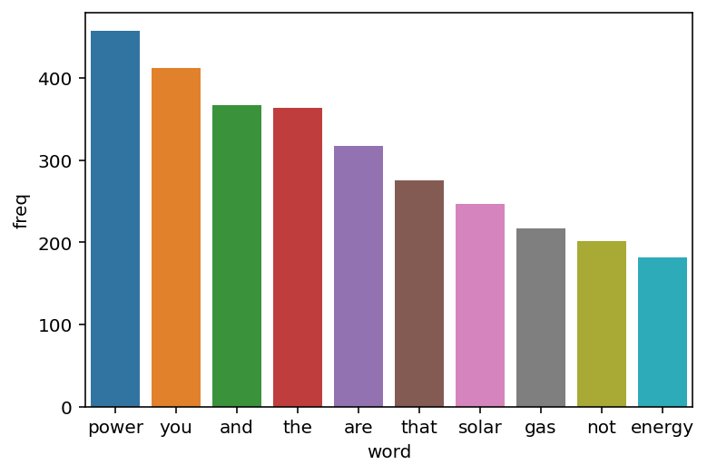

```python
sns.barplot(x=freq_r["word"][:10].sort_index(ascending=True),y=freq_r['freq'])
```

The barplot shows the top 10 word counts. `Power` is the highest common word appears on the dataset. However, you can see there are lots of meaningless words, like `you`,`and`,`the`,`are`,`that`,`not`. Those word are showned out because the countvectorizer only count the freqency of each words and it does not consider the type of words.

**Wordcloud**

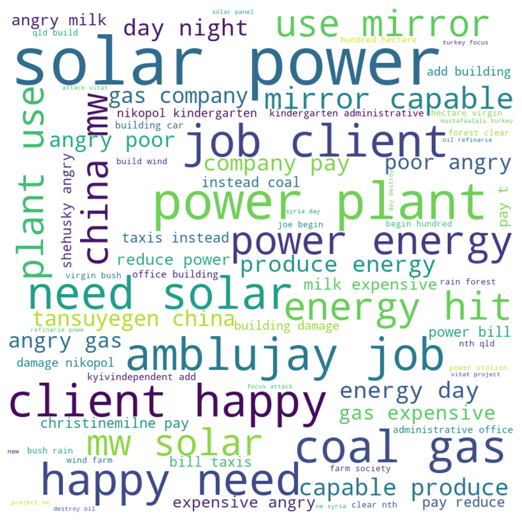

```python
comment_words = ''
w = WordCloud()
stop_words = list(w.stopwords)
custom_stop_words = ['https', 'rt','website']
stopwords = set(stop_words + custom_stop_words)

# iterate through the csv file
for val in stmr.clean_text:

    # typecaste each val to string
    val = str(val)

    # split the value
    tokens = val.split()

    # Converts each token into lowercase
    for i in range(len(tokens)):
        tokens[i] = tokens[i].lower()

    comment_words += " ".join(tokens)+" "

wordcloud = WordCloud(width = 800, height = 800,
                background_color ='white',
                stopwords = stopwords,
                min_font_size = 10).generate(comment_words)

# plot the WordCloud image
plt.figure(figsize = (8, 8), facecolor = None)
plt.imshow(wordcloud)
plt.axis("off")
plt.tight_layout(pad = 0)

plt.show()
```

From the wordcloud, we can see that the most common word is `solar` and `power`. people seems like highly interested in this two word-related things. Also, there appear `angry` and `expensive` those kind of emotion or altittude words.

**Pie chart about the sentiment counts**

[figure not shown]

```python
conditions = [
    (stmr['compound'] >= 0.33),
    (stmr['compound'] <= -0.33),
    (stmr['compound'] > -0.33) & (stmr['compound'] < 0.33),
]

values = ['positive', 'negative', 'neutral']

stmr["sentiment"] = np.select(conditions, values)

pie = stmr.sentiment.value_counts().plot(kind = "pie",autopct='%1.0f%%')
pie.set_title("Twitter Userss' Attitudes",fontdict= { 'fontsize': 20,'fontweight':'bold'})
```

From the pie chart, you can clearly notice that there are 64% users’ with negative sentiment, and only 31% people positive sentiment.

Nowadays, the inflation after Covid-19 era makes every expensive than the past, the high payment of utilities of house or eergy consumption can make people streeful. Will this increasing payment make people use less energy? This still need to be justified. However, people is considering more about solar power which is a type of clean energy whic we direcly get from sunlight. This power is environmentally friendly and also sustainable. Government should promote these kind of clean energy in helping society to reduce the CO2 emission and save unrenewable energy.

### Twitter users’ dataset grathered from Python

**Load packages and dataset**

```python
from matplotlib import pyplot as plt
import seaborn as sns
import pandas as pd
import numpy as np
import warnings
warnings.filterwarnings('ignore')
from wordcloud import WordCloud, STOPWORDS
import matplotlib.pyplot as plt
import pandas as pd

freq_py = pd.read_csv("/Users/crystal/Desktop/anly-501-project-HuitingSong/501-project-website/data/cleaned data/countword.csv").drop("Unnamed: 0",axis=1)

stmpy = pd.read_csv("/Users/crystal/Desktop/anly-501-project-HuitingSong/501-project-website/data/cleaned data/pystmscore.csv",index_col=[0])
```

**Dataset preview**

```python
print("The word frequency dataset:",freq_py.head())
print("The sentiment score dataset:",stmpy.head())
```

```
The word frequency dataset:           words  counts
0          zero     654
1  yuugiriawano     653
2          year     652
3      yanqinyq     651
4           xrp     650
The sentiment score dataset:                                                 text  \
0  The Croatian team had an unfair advantage due ...
1  @crypto_pylon 📣🥳We are proud to announce a new...
2  @BTCPriceUp 📣🥳We are proud to announce a new t...
3  @JustCanadian7 @RobCairns10 @LouisGeorgeVonB @...
4  @BNB_Tracker 📣🥳We are proud to announce a new ...

                                          clean_text    neg    neu    pos  \
0  croatian team unfair advantage consumption ara...  0.109  0.598  0.293
1  cryptopylon proud announce new token bear caso...  0.062  0.665  0.272
2  btcpriceup proud announce new token bear casol...  0.044  0.692  0.264
3  justcanadian robcairns louisgeorgevonb jasonhi...  0.033  0.691  0.276
4  bnbtracker proud announce new token bear casol...  0.027  0.702  0.271

   compound
0    0.4970
1    0.8135
2    0.9121
3    0.9579
4    0.9723
```

**barplot of the word frequency** - top 10 counts of words

[output not shown]

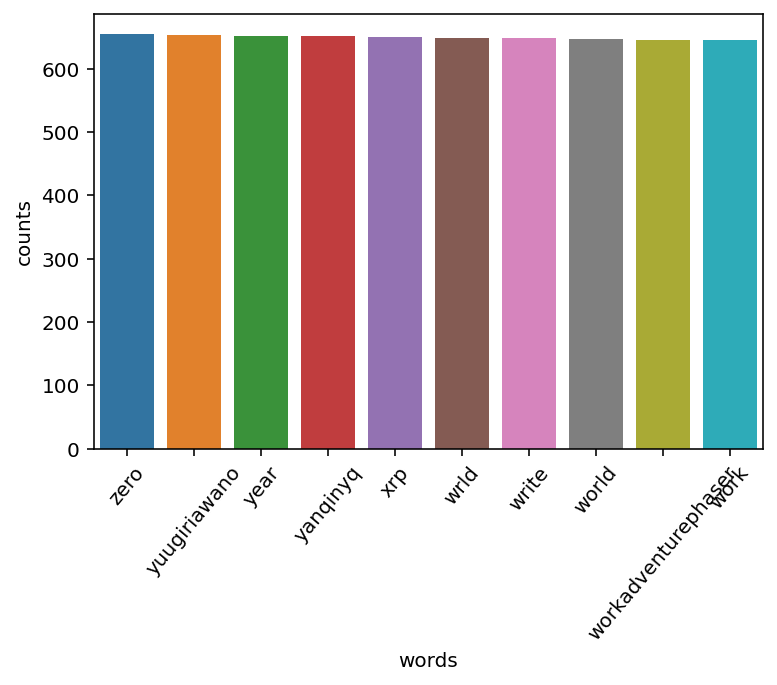

```python
sns.barplot(x=freq_py["words"][:10].sort_index(ascending=True),y=freq_py['counts'])
plt.xticks(rotation=50)
```

As we can see in ths barplot, the word with highest counts are still mostly meaningless in understanding.

**Wordcloud**

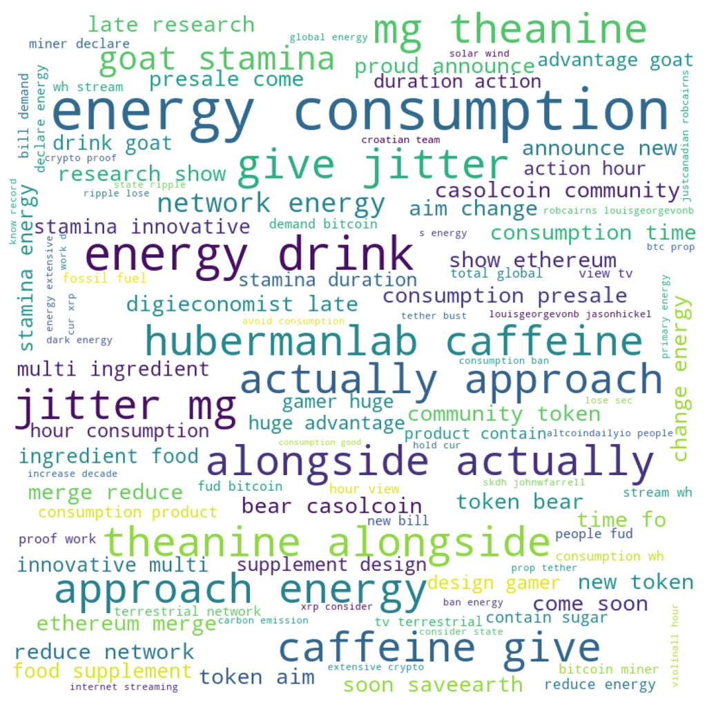

```python
comment_words = ''
w = WordCloud()
stop_words = list(w.stopwords)
custom_stop_words = ['https', 'rt','website']
stopwords = set(stop_words + custom_stop_words)

# iterate through the csv file
for val in stmpy.clean_text:

    # typecaste each val to string
    val = str(val)

    # split the value
    tokens = val.split()

    # Converts each token into lowercase
    for i in range(len(tokens)):
        tokens[i] = tokens[i].lower()

    comment_words += " ".join(tokens)+" "

wordcloud = WordCloud(width = 800, height = 800,
                background_color ='white',
                stopwords = stopwords,
                min_font_size = 10).generate(comment_words)

# plot the WordCloud image
plt.figure(figsize = (8, 8), facecolor = None)
plt.imshow(wordcloud)
plt.axis("off")
plt.tight_layout(pad = 0)

plt.show()
```

**Pie chart about the sentiment counts**

[figure not shown]

```python
conditions = [
    (stmpy['compound'] >= 0.33),
    (stmpy['compound'] <= -0.33),
    (stmpy['compound'] > -0.33) & (stmpy['compound'] < 0.33),
]

values = ['positive', 'negative', 'neutral']

stmpy["sentiment"] = np.select(conditions, values)

pie = stmpy.sentiment.value_counts().plot(kind = "pie",autopct='%1.0f%%')
pie.set_title("Twitter Userss' Attitudes",fontdict= { 'fontsize': 20,'fontweight':'bold'})
```

From the pie chart, the sentiment for twitter users’ are 100% positive. I think may somethinsg wrong with the sentiment analysis. However, I do do not see the negative words in the wordcloud.

Nowadays, the envirnment is under huge challenge due to human actions, and also the energy we usually use is facing the problem of unrenewable. Saving the energy and environment is good for everyone of us. People now is thinking about the actions and ideas to reach the blueprint of better home, so we all need to have positive sentiment in make our Earth better.